# France Rental Deserts — Figures 1–5

dawon

2026-06-01

```r
# ── UPDATE THIS ONE PATH ──────────────────────────────────────────────────────
base_path <- "C:/Users/ohdaw/OneDrive/Documents/R_Projects/rental_desert/France/"
# ─────────────────────────────────────────────────────────────────────────────

# Output directory for saved PNGs (created if absent)
fig_dir <- paste0(base_path, "figures/")
if (!dir.exists(fig_dir)) dir.create(fig_dir)

# Figure 3 city selector — change to any lib2020 name or UU2020 code
FIGURE3_CITY <- "Paris"   # e.g. "Lyon", "Marseille-Aix-en-Provence", …

# File paths
path_pop_shp    <- paste0(base_path, "Updated_IRIS_with_Population.shp")
path_rental_csv <- paste0(base_path, "france_rental.csv")
path_income_csv <- paste0(base_path, "Updated_IRIS_with_Income.csv")
path_iris_poly  <- paste0(base_path, "Updated_Combined_Data.shp")
path_uu_shp     <- paste0(base_path, "France_maps/uu_without_overseas/uu_without_overseas.shp")
```

# 0 Shared colour palettes

```r
# Figure 1 — tenure type bars (light → dark)
pal_tenure <- c(
  "Rental Deserts"            = "#D5C4D6",
  "Mixed-Tenure\nNeighborhoods" = "#9B6B9B",
  "High-Rental\nNeighborhoods"  = "#3D1A5E"
)

# Figures 2 — divergence quartile (light blue → dark purple)
pal_quartile <- c(
  "Least Divergent" = "#DEEAF5",
  "Second Quartile" = "#9ECAE1",
  "Third Quartile"  = "#6A51A3",
  "Most Divergent"  = "#3D0966"
)

# Figure 3 — IRIS divergence type (4 categories + NA)
pal_iris_type <- c(
  "Most Divergent,\nHigh Rental"  = "#08306B",
  "Most Divergent,\nHigh Owner"   = "#54278F",
  "Less Divergent,\nHigh Rental"  = "#9ECAE1",
  "Less Divergent,\nHigh Owner"   = "#BCBDDC"
)

# Figures 4 & 5 — 2×2 segregation type (dark → light)
make_seg_pal <- function(label) {
  setNames(
    c("#4B0082", "#9B6BAB", "#AEC6D8", "#DCE8F4"),
    c(
      paste0("High Housing,\nHigh ", label),
      paste0("High Housing,\nLow ",  label),
      paste0("Low Housing,\nHigh ",  label),
      paste0("Low Housing,\nLow ",   label)
    )
  )
}
pal_seg_income   <- make_seg_pal("Income\nSegregation")
pal_seg_building <- make_seg_pal("Building Age\nSegregation")
```

```r
# Shared ggplot theme for all choropleth maps
theme_map <- function(legend_pos = c(0.14, 0.25)) {
  theme_void() +
    theme(
      legend.position      = legend_pos,
      legend.justification = c(0, 0.5),
      legend.title         = element_text(size = 8, face = "bold",
                                          lineheight = 1.1),
      legend.text          = element_text(size = 7.5),
      legend.key.size      = unit(0.35, "cm"),
      legend.spacing.y     = unit(0.15, "cm"),
      plot.background      = element_rect(fill = "white", color = NA),
      panel.background     = element_rect(fill = "white", color = NA),
      plot.margin          = margin(4, 4, 4, 4)
    )
}

# Shared theme for the bar chart
theme_bar <- function() {
  theme_minimal(base_size = 11) +
    theme(
      panel.grid.major.x = element_blank(),
      panel.grid.minor   = element_blank(),
      panel.grid.major.y = element_line(colour = "grey88", linetype = "dashed"),
      axis.line.x        = element_line(colour = "grey60", size = 0.3),
      axis.ticks.x       = element_line(colour = "grey60", size = 0.3),
      axis.text          = element_text(size = 9),
      axis.title.x       = element_text(size = 9, margin = margin(t = 6)),
      axis.title.y       = element_blank(),
      legend.position    = "bottom",
      legend.title       = element_blank(),
      legend.text        = element_text(size = 8),
      legend.key.size    = unit(0.4, "cm"),
      legend.spacing.x   = unit(0.3, "cm"),
      plot.background    = element_rect(fill = "white", color = NA)
    )
}
```

# 1 Load and prepare data

```r
# ── IRIS point data + rental variables (mirrors France_DiverseIndex.Rmd) ──────
iris_pop <- st_read(path_pop_shp, quiet = TRUE)
france_rental <- read_csv(path_rental_csv, show_col_types = FALSE)

iris_df <- iris_pop %>%
  left_join(france_rental, by = c("CODE_IR" = "IRIS")) %>%
  select(-ends_with(".y")) %>%
  rename_with(~ gsub("\\.x$", "", .)) %>%
  mutate(
    across(c(P21_PMEN, rental_sh, P21_RP, P21_RPMAISON,
             P21_RPAPPART, P21_LOGVAC, P21_LOG,
             P21_RP_ACH19, P21_RP_ACH45, P21_RP_ACH70,
             P21_RP_ACH90, P21_RP_ACH05, P21_RP_ACH18,
             P21_RP_ACHTOT), as.numeric),
    rental_sh = pmax(0, pmin(100, rental_sh)),   # clamp to [0,100]
    owner_sh  = 100 - rental_sh,
    tenure_type = case_when(
      rental_sh <  20 ~ "Rental Deserts",
      rental_sh >= 80 ~ "High-Rental\nNeighborhoods",
      TRUE            ~ "Mixed-Tenure\nNeighborhoods"
    ),
    tenure_type = factor(tenure_type,
      levels = c("Rental Deserts",
                 "Mixed-Tenure\nNeighborhoods",
                 "High-Rental\nNeighborhoods"))
  ) %>%
  st_drop_geometry()
```

```r
# ── Top-100 UUs by population ─────────────────────────────────────────────────
top_100_uu <- iris_df %>%
  group_by(UU2020) %>%
  summarise(total_pop = sum(P21_PMEN, na.rm = TRUE),
            lib2020   = first(lib2020), .groups = "drop") %>%
  arrange(desc(total_pop)) %>%
  slice_head(n = 100)

# ── Metro-level rental shares ─────────────────────────────────────────────────
metro_shares <- iris_df %>%
  filter(UU2020 %in% top_100_uu$UU2020) %>%
  group_by(UU2020) %>%
  summarise(metro_rental_sh = mean(rental_sh, na.rm = TRUE),
            metro_owner_sh  = 100 - metro_rental_sh, .groups = "drop")

# ── IRIS-level divergence (same formula as France_DiverseIndex.Rmd) ───────────
divergence_values <- iris_df %>%
  filter(UU2020 %in% top_100_uu$UU2020) %>%
  left_join(metro_shares, by = "UU2020") %>%
  mutate(
    divergence_value = rental_sh * log(rental_sh / metro_rental_sh) +
                       owner_sh  * log(owner_sh  / metro_owner_sh)
  )

# ── Metro-level divergence (population-weighted mean) ────────────────────────
metro_divergence <- divergence_values %>%
  group_by(UU2020) %>%
  summarise(
    avg_divergence_value = weighted.mean(divergence_value,
                                         w = P21_PMEN, na.rm = TRUE),
    .groups = "drop"
  ) %>%
  mutate(
    div_quartile = ntile(avg_divergence_value, 4),
    div_category = factor(
      case_when(
        div_quartile == 1 ~ "Least Divergent",
        div_quartile == 2 ~ "Second Quartile",
        div_quartile == 3 ~ "Third Quartile",
        div_quartile == 4 ~ "Most Divergent"
      ),
      levels = c("Least Divergent", "Second Quartile",
                 "Third Quartile",  "Most Divergent")
    )
  )

cat("Metro divergence computed for", nrow(metro_divergence), "urban units\n")
```

```
## Metro divergence computed for 100 urban units
```

```r
# ── Income divergence (mirrors France_DiverseIndex.Rmd) ──────────────────────
income_raw <- read_csv(path_income_csv, show_col_types = FALSE)

income_iris <- income_raw %>%
  filter(UU2020 %in% top_100_uu$UU2020) %>%
  mutate(income_cat = case_when(
    DEC_MED21 <  20000 ~ "Lower",
    DEC_MED21 <  40000 ~ "Middle",
    !is.na(DEC_MED21)  ~ "Higher",
    TRUE               ~ NA_character_
  )) %>%
  filter(!is.na(income_cat))

income_shares <- income_iris %>%
  group_by(UU2020, income_cat) %>%
  summarise(count = n(), .groups = "drop") %>%
  group_by(UU2020) %>%
  mutate(iris_share = count / sum(count)) %>%
  ungroup()

metro_income_ref <- income_shares %>%
  group_by(income_cat) %>%
  summarise(metro_share = mean(iris_share, na.rm = TRUE), .groups = "drop")

income_divergence <- income_shares %>%
  left_join(metro_income_ref, by = "income_cat") %>%
  mutate(component = iris_share * log(iris_share / metro_share)) %>%
  group_by(UU2020) %>%
  summarise(income_divergence_index = sum(component, na.rm = TRUE),
            .groups = "drop")
```

```r
# ── Building age entropy (mirrors France_DiverseIndex.Rmd) ───────────────────
building_age_divergence <- iris_df %>%
  filter(UU2020 %in% top_100_uu$UU2020) %>%
  mutate(
    s19 = P21_RP_ACH19 / P21_RP_ACHTOT,
    s45 = P21_RP_ACH45 / P21_RP_ACHTOT,
    s70 = P21_RP_ACH70 / P21_RP_ACHTOT,
    s90 = P21_RP_ACH90 / P21_RP_ACHTOT,
    s05 = P21_RP_ACH05 / P21_RP_ACHTOT,
    s18 = P21_RP_ACH18 / P21_RP_ACHTOT
  ) %>%
  rowwise() %>%
  mutate(bldg_entropy = -sum(
    c(s19, s45, s70, s90, s05, s18) *
    log(c(s19, s45, s70, s90, s05, s18)),
    na.rm = TRUE)) %>%
  ungroup() %>%
  group_by(UU2020) %>%
  summarise(building_age_divergence_index = mean(bldg_entropy, na.rm = TRUE),
            .groups = "drop")
```

# 2 Figure 1 — Average Income Distribution by Tenure Type

**French equivalent of Fig 1**: For each income category (classified by IRIS median income), shows the share of IRIS falling into each tenure type. Y-axis mirrors the reference (“Average Share, percent”).

```r
# Join income category to IRIS data
iris_income <- income_iris %>%
  select(CODE_IR, income_cat, UU2020) %>%
  right_join(
    iris_df %>% select(CODE_IR, tenure_type),
    by = "CODE_IR"
  ) %>%
  filter(!is.na(income_cat))

# For each income_cat × tenure_type: % of IRIS in that tenure type
fig1_data <- iris_income %>%
  group_by(income_cat, tenure_type) %>%
  summarise(n = n(), .groups = "drop") %>%
  group_by(income_cat) %>%
  mutate(pct = n / sum(n) * 100) %>%
  ungroup() %>%
  mutate(
    income_cat = factor(
      income_cat,
      levels = c("Lower", "Middle", "Higher"),
      labels = c("Less than €20,000",
                 "€20,000–€39,999",
                 "€40,000 or More")
    )
  )
```

[figure not shown]

```r
fig1 <- ggplot(fig1_data,
               aes(x = income_cat, y = pct, fill = tenure_type)) +
  geom_col(position = position_dodge(width = 0.7),
           width = 0.65, colour = NA) +
  scale_fill_manual(
    values = pal_tenure,
    labels = c("Rental Deserts",
               "Mixed-Tenure Neighborhoods",
               "High-Rental Neighborhoods")
  ) +
  scale_y_continuous(
    limits   = c(0, 70),
    breaks   = seq(0, 60, 20),
    expand   = expansion(mult = c(0, 0.02))
  ) +
  labs(
    title = "Average Share of IRIS (Percent)",
    x     = "Household Income (IRIS Median)"
  ) +
  theme_bar() +
  guides(fill = guide_legend(nrow = 1))

fig1
```

```r
ggsave(paste0(fig_dir, "Figure1_income_tenure.png"),
       fig1, width = 6.5, height = 4, dpi = 300, bg = "white")
```

# 3 Figure 2 — Housing Tenure Divergence Index Across Urban Units

**French equivalent of Fig 2**: national map of the 100 largest urban units (UU2020) coloured by divergence index quartile.

```r
uu_shp <- st_read(path_uu_shp, quiet = TRUE) %>%
  st_transform(crs = 4326)

# All UUs: grey background; top-100 UUs: coloured by quartile
uu_map_data <- uu_shp %>%
  left_join(
    metro_divergence %>% select(UU2020, div_category),
    by = c("uu2020" = "UU2020")
  ) %>%
  mutate(
    fill_var = if_else(!is.na(div_category),
                       as.character(div_category),
                       "Other urban units")
  )

# France bounding box (mainland only)
fr_bbox <- st_bbox(uu_shp)
```

```r
fig2 <- ggplot(uu_map_data) +
  # All non-top-100 UUs: light grey background
  geom_sf(data = filter(uu_map_data, fill_var == "Other urban units"),
          fill = "#EEEEEE", colour = NA) +
  # Top-100 UUs: coloured
  geom_sf(data = filter(uu_map_data, fill_var != "Other urban units"),
          aes(fill = fill_var), colour = "white", linewidth = 0.1) +
  scale_fill_manual(
    name   = "Divergence Index\nValue (Quartile)",
    values = pal_quartile,
    breaks = names(pal_quartile),
    na.value = "#EEEEEE"
  ) +
  coord_sf(
    xlim = c(fr_bbox["xmin"] - 0.3, fr_bbox["xmax"] + 0.3),
    ylim = c(fr_bbox["ymin"] - 0.3, fr_bbox["ymax"] + 0.3),
    expand = FALSE
  ) +
  theme_map()

fig2
ggsave(paste0(fig_dir, "Figure2_divergence_national.png"),
       fig2, width = 7.5, height = 5.5, dpi = 300, bg = "white")
```

```r
# The uu2020 shapefile codes don't match UU2020 in the IRIS data (47/100 match).
# Fix: dissolve IRIS polygon boundaries by u2020_x (= UU2020 in IRIS data)
# to build UU-level geometries that are guaranteed to use the same codes.

if (!exists("iris_poly")) {
  iris_poly <- st_read(path_iris_poly, quiet = TRUE) %>%
    st_transform(crs = 4326)
}

# Dissolve top-100 IRIS to UU-level polygons (takes ~1 min)
uu_polygons <- iris_poly %>%
  filter(u2020_x %in% top_100_uu$UU2020) %>%
  group_by(u2020_x) %>%
  summarise(geometry = st_union(geometry), .groups = "drop") %>%
  left_join(
    metro_divergence %>% select(UU2020, div_category),
    by = c("u2020_x" = "UU2020")
  ) %>%
  mutate(fill_var = factor(div_category, levels = names(pal_quartile)))

cat("UU polygons built:", nrow(uu_polygons), "\n")
```

```
## UU polygons built: 100
```

```r
cat("Categories:\n"); print(table(uu_polygons$fill_var, useNA = "ifany"))
```

```
## Categories:
```

```
##
## Least Divergent Second Quartile  Third Quartile  Most Divergent
##              25              25              25              25
```

```r
# Grey background: all IRIS not in top-100 UUs
iris_bg  <- iris_poly %>% filter(!u2020_x %in% top_100_uu$UU2020)
fr_bbox  <- st_bbox(c(xmin=-5.2, xmax=9.7, ymin=41.2, ymax=51.2), crs=4326)
```

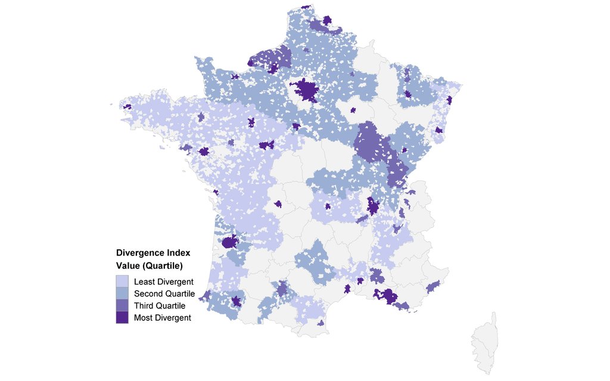

```r
# ── Figure 2 (reference style) ───────────────────────────────────────────────
library(maps)

france_bg <- st_as_sf(map("france", plot = FALSE, fill = TRUE)) %>%
  st_transform(crs = 4326) %>%
  st_make_valid()   # fixes any topology issues in the map data

# Then the rest of the chunk continues unchanged:
pal_q2 <- c(
  "Least Divergent" = "#C6CBEF",
  "Second Quartile" = "#9BAFD4",
  "Third Quartile"  = "#756BB1",
  "Most Divergent"  = "#54278F"
)

fig2 <- ggplot() +
  geom_sf(data = france_bg,
          fill      = "#F2F2F2",
          colour    = "#BEBEBE",
          linewidth = 0.15) +
  geom_sf(data = uu_polygons,
          aes(fill = fill_var),
          colour    = NA,
          linewidth = 0.05) +
  scale_fill_manual(
    name     = "Divergence Index\nValue (Quartile)",
    values   = pal_q2,
    drop     = FALSE,
    na.value = "#D4D4D4"
  ) +
  coord_sf(xlim = c(-5.2, 9.7), ylim = c(41.2, 51.2), expand = FALSE) +
  theme_void() +
  theme(
    plot.background      = element_rect(fill = "white", colour = NA),
    panel.background     = element_rect(fill = "white", colour = NA),
    legend.position      = c(0.02, 0.25),
    legend.justification = c(0, 0.5),
    legend.title         = element_text(size = 8.5, face = "bold",
                                        lineheight = 1.2),
    legend.text          = element_text(size = 8),
    legend.key.size      = unit(0.4, "cm"),
    legend.key           = element_rect(colour = "grey60", linewidth = 0.3),
    legend.background    = element_rect(fill = "white", colour = NA),
    legend.spacing.y     = unit(0.1, "cm")
  )

fig2
```

```r
ggsave(paste0(fig_dir, "Figure2_divergence_national.png"),
       fig2, width = 15, height = 11, dpi = 300, bg = "white")
```

# 4 Figure 3 — Neighborhood Divergence Type: Paris

**French equivalent of Fig 3**: IRIS-level map for one metro, classifying each IRIS by whether it is Most/Less Divergent and High Rental/High Owner. Quartiles are computed *within* the selected metro.

```r
# Load IRIS polygon boundaries
iris_poly <- st_read(path_iris_poly, quiet = TRUE) %>%
  st_transform(crs = 4326)

# Find the UU2020 code for the selected city
target_uu <- top_100_uu %>%
  filter(str_detect(lib2020, fixed(FIGURE3_CITY, ignore_case = TRUE))) %>%
  pull(UU2020)

if (length(target_uu) == 0) {
  stop("City '", FIGURE3_CITY,
       "' not found in top-100 UUs. Check lib2020 names with: top_100_uu$lib2020")
}
cat("Mapping:", FIGURE3_CITY, "— UU2020 code:", target_uu[1], "\n")
```

```
## Mapping: Paris — UU2020 code: 00851
```

```r
# IRIS divergence for this metro, with within-metro quartile split
iris_city_div <- divergence_values %>%
  filter(UU2020 == target_uu[1]) %>%
  mutate(
    div_quartile = ntile(divergence_value, 4),
    iris_type    = case_when(
      div_quartile == 4 & rental_sh > owner_sh ~
        "Most Divergent,\nHigh Rental",
      div_quartile == 4 & rental_sh <= owner_sh ~
        "Most Divergent,\nHigh Owner",
      div_quartile < 4 & rental_sh > owner_sh ~
        "Less Divergent,\nHigh Rental",
      TRUE ~
        "Less Divergent,\nHigh Owner"
    ),
    iris_type = factor(iris_type, levels = names(pal_iris_type))
  ) %>%
  select(CODE_IR, iris_type)

# Join to polygon geometry
iris_city_map <- iris_poly %>%
  filter(u2020_x == target_uu[1]) %>%
  left_join(iris_city_div, by = "CODE_IR")
```

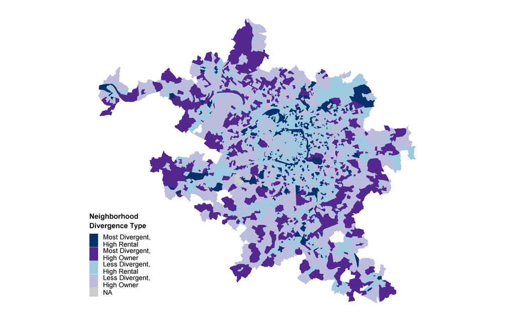

```r
#fig3 <- ggplot(iris_city_map) +
  #geom_sf(aes(fill = iris_type), colour = "grey60", linewidth = 0.05) +

fig3 <- ggplot(iris_city_map) +
  geom_sf(aes(fill = iris_type), colour = NA, linewidth = 0.05) +
  scale_fill_manual(
    name     = "Neighborhood\nDivergence Type",
    values   = pal_iris_type,
    na.value = "#CCCCCC",
    na.translate = TRUE,
    labels   = c(names(pal_iris_type), "NA")
  ) +
  theme_map(legend_pos = c(0.02, 0.2))

fig3
```

```r
ggsave(paste0(fig_dir, paste0("Figure3_iris_map_", FIGURE3_CITY, ".png")),
       fig3, width = 13, height = 12, dpi = 900, bg = "white")
```

# 5 Figure 4 — Housing Tenure × Building Age Segregation

```r
# figure4-data — replace the uu_bldg_map line:
uu_bldg_map <- uu_polygons %>%
  left_join(seg_bldg %>% select(UU2020, seg_type),
            by = c("u2020_x" = "UU2020"))

# figure5-data — replace the uu_income_map line:
uu_income_map <- uu_polygons %>%
  left_join(seg_income %>% select(UU2020, seg_type),
            by = c("u2020_x" = "UU2020"))
```

```r
housing_threshold   <- median(metro_divergence$avg_divergence_value,       na.rm = TRUE)
building_threshold  <- median(building_age_divergence$building_age_divergence_index,
                               na.rm = TRUE)

seg_bldg <- metro_divergence %>%
  left_join(building_age_divergence, by = "UU2020") %>%
  mutate(
    seg_type = case_when(
      avg_divergence_value >= housing_threshold &
        building_age_divergence_index >= building_threshold ~
        "High Housing,\nHigh Building Age\nSegregation",
      avg_divergence_value >= housing_threshold &
        building_age_divergence_index <  building_threshold ~
        "High Housing,\nLow Building Age\nSegregation",
      avg_divergence_value <  housing_threshold &
        building_age_divergence_index >= building_threshold ~
        "Low Housing,\nHigh Building Age\nSegregation",
      TRUE ~
        "Low Housing,\nLow Building Age\nSegregation"
    ),
    seg_type = factor(seg_type, levels = names(pal_seg_building))
  )

uu_bldg_map <- uu_shp %>%
  left_join(
    seg_bldg %>% select(UU2020, seg_type),
    by = c("uu2020" = "UU2020")
  )
```

```r
uu_polygons <- iris_poly %>%
  rename(UU2020 = u2020_x) %>%
  mutate(UU2020 = as.character(UU2020)) %>%
  filter(!is.na(UU2020), UU2020 != "0", UU2020 != "") %>%
  group_by(UU2020) %>%
  summarise(geometry = st_union(geometry), .groups = "drop")

cat("UU polygons built:", nrow(uu_polygons), "\n")
```

```
## UU polygons built: 2495
```

```r
cat("Previously unmatched codes now found:",
    sum(c("01000","02000","31000","33000") %in% uu_polygons$UU2020), "/ 4\n")
```

```
## Previously unmatched codes now found: 4 / 4
```

```r
# In the Figure 3 data chunk, filter line currently reads:
#   filter(u2020_x == target_uu[1])
# Change to:
iris_city_map <- iris_poly %>%
  filter(as.character(u2020_x) == target_uu[1]) %>%
  left_join(iris_city_div, by = "CODE_IR")
```

```r
# Use same color palette as Figure 2
pal_seg_building <- c(
  "Low Housing, Low Building Age Segregation"   = "#C6CBEF",
  "Low Housing, High Building Age Segregation"  = "#9BAFD4",
  "High Housing, Low Building Age Segregation"  = "#756BB1",
  "High Housing, High Building Age Segregation" = "#54278F"
)

# Background metros
uu_background <- uu_polygons %>%
  filter(!UU2020 %in% seg_bldg$UU2020)

# Highlighted metros
uu_fig4_map <- uu_polygons %>%
  filter(UU2020 %in% seg_bldg$UU2020) %>%
  left_join(
    seg_bldg %>% select(UU2020, seg_type),
    by = "UU2020"
  ) %>%
  mutate(
    seg_type = stringr::str_squish(as.character(seg_type)),
    seg_type = factor(seg_type, levels = names(pal_seg_building))
  )

cat("Coloured UUs:", nrow(uu_fig4_map), "\n")
```

```
## Coloured UUs: 100
```

```r
print(table(uu_fig4_map$seg_type, useNA = "ifany"))
```

```
##
##   Low Housing, Low Building Age Segregation
##                                           0
##  Low Housing, High Building Age Segregation
##                                           0
##  High Housing, Low Building Age Segregation
##                                           0
## High Housing, High Building Age Segregation
##                                           0
##                                        <NA>
##                                         100
```

[figure not shown]

```r
fig4 <- ggplot() +
  geom_sf(
    data = france_bg,
    fill = "#F2F2F2",
    colour = "#BEBEBE",
    linewidth = 0.15
  ) +
  geom_sf(
    data = uu_background,
    fill = "#F2F2F2",
    colour = "#BEBEBE",
    linewidth = 0.15
  ) +
  geom_sf(
    data = uu_fig4_map,
    aes(fill = seg_type),
    colour = NA,
    linewidth = 0.05
  ) +
  scale_fill_manual(
    name = "Segregation Type",
    values = pal_seg_building,
    drop = FALSE,
    na.value = "#D4D4D4"
  ) +
  coord_sf(
    xlim = c(-5.2, 9.7),
    ylim = c(41.2, 51.2),
    expand = FALSE
  ) +
  theme_void() +
  theme(
    plot.background      = element_rect(fill = "white", colour = NA),
    panel.background     = element_rect(fill = "white", colour = NA),
    legend.position      = c(0.02, 0.25),
    legend.justification = c(0, 0.5),
    legend.title         = element_text(size = 8.5, face = "bold", lineheight = 1.2),
    legend.text          = element_text(size = 8),
    legend.key.size      = unit(0.4, "cm"),
    legend.key           = element_rect(colour = "grey60", linewidth = 0.3),
    legend.background    = element_rect(fill = NA, colour = NA),
    legend.spacing.y     = unit(0.1, "cm")
  )

fig4
```

```r
ggsave(
  paste0(fig_dir, "Figure4_housing_building_age_seg.png"),
  fig4,
  width = 15,
  height = 11,
  dpi = 300,
  bg = "white"
)
```

# 6 Figure 5 — Housing Tenure × Income Segregation

**French equivalent of Fig 5**: same 2×2 classification using income divergence instead of building age.

```r
income_threshold <- median(income_divergence$income_divergence_index, na.rm = TRUE)

seg_income <- metro_divergence %>%
  left_join(income_divergence, by = "UU2020") %>%
  mutate(
    seg_type = case_when(
      avg_divergence_value >= housing_threshold &
        income_divergence_index >= income_threshold ~
        "High Housing,\nHigh Income\nSegregation",
      avg_divergence_value >= housing_threshold &
        income_divergence_index <  income_threshold ~
        "High Housing,\nLow Income\nSegregation",
      avg_divergence_value <  housing_threshold &
        income_divergence_index >= income_threshold ~
        "Low Housing,\nHigh Income\nSegregation",
      TRUE ~
        "Low Housing,\nLow Income\nSegregation"
    ),
    seg_type = factor(seg_type, levels = names(pal_seg_income))
  )

uu_income_map <- uu_shp %>%
  left_join(
    seg_income %>% select(UU2020, seg_type),
    by = c("uu2020" = "UU2020")
  )
```

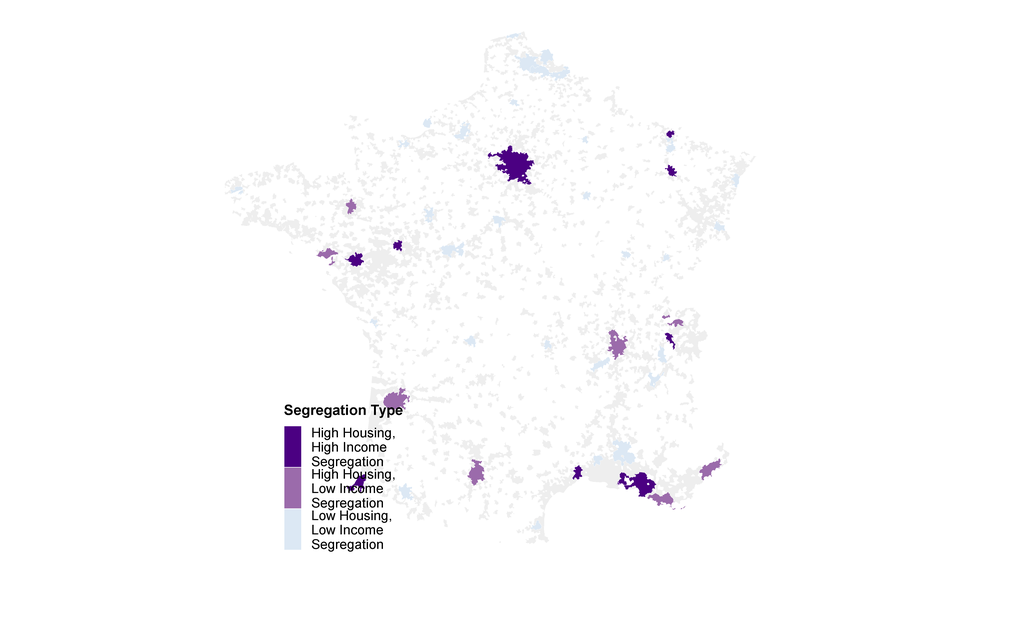

```r
fig5 <- ggplot(uu_income_map) +
  geom_sf(data = filter(uu_income_map, is.na(seg_type)),
          fill = "#EEEEEE", colour = NA) +
  geom_sf(data = filter(uu_income_map, !is.na(seg_type)),
          aes(fill = seg_type), colour = "white", linewidth = 0.1) +
  scale_fill_manual(
    name   = "Segregation Type",
    values = pal_seg_income,
    na.value = "#EEEEEE"
  ) +
  coord_sf(
    xlim   = c(fr_bbox["xmin"] - 0.3, fr_bbox["xmax"] + 0.3),
    ylim   = c(fr_bbox["ymin"] - 0.3, fr_bbox["ymax"] + 0.3),
    expand = FALSE
  ) +
  theme_map()

fig5
```

```r
ggsave(paste0(fig_dir, "Figure5_housing_income_seg.png"),
       fig5, width = 7.5, height = 5.5, dpi = 300, bg = "white")
```

```r
# ── Figure 5 — Housing Tenure × Income Segregation, same style as Figure 4 ──

pal_seg_income <- c(
  "Low Housing, Low Income Segregation"   = "#C6CBEF",
  "Low Housing, High Income Segregation"  = "#9BAFD4",
  "High Housing, Low Income Segregation"  = "#756BB1",
  "High Housing, High Income Segregation" = "#54278F"
)

income_threshold <- median(
  income_divergence$income_divergence_index,
  na.rm = TRUE
)

seg_income <- metro_divergence %>%
  left_join(income_divergence, by = "UU2020") %>%
  mutate(
    seg_type = case_when(
      avg_divergence_value >= housing_threshold &
        income_divergence_index >= income_threshold ~
        "High Housing, High Income Segregation",

      avg_divergence_value >= housing_threshold &
        income_divergence_index < income_threshold ~
        "High Housing, Low Income Segregation",

      avg_divergence_value < housing_threshold &
        income_divergence_index >= income_threshold ~
        "Low Housing, High Income Segregation",

      TRUE ~
        "Low Housing, Low Income Segregation"
    ),
    seg_type = stringr::str_squish(as.character(seg_type)),
    seg_type = factor(seg_type, levels = names(pal_seg_income))
  )

uu_income_background <- uu_polygons %>%
  filter(!UU2020 %in% seg_income$UU2020)

uu_income_map <- uu_polygons %>%
  filter(UU2020 %in% seg_income$UU2020) %>%
  left_join(
    seg_income %>% select(UU2020, seg_type),
    by = "UU2020"
  ) %>%
  mutate(
    seg_type = factor(seg_type, levels = names(pal_seg_income))
  )

cat("Coloured UUs:", nrow(uu_income_map), "\n")
```

```
## Coloured UUs: 100
```

```r
print(table(uu_income_map$seg_type, useNA = "ifany"))
```

```
##
##   Low Housing, Low Income Segregation  Low Housing, High Income Segregation
##                                    83                                     0
##  High Housing, Low Income Segregation High Housing, High Income Segregation
##                                     8                                     9
```

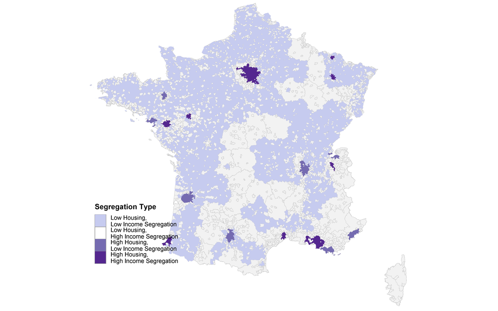

```r
fig5 <- ggplot() +
  geom_sf(
    data = france_bg,
    fill = "#F2F2F2",
    colour = "#BEBEBE",
    linewidth = 0.15
  ) +
  geom_sf(
    data = uu_income_background,
    fill = "#F2F2F2",
    colour = "#BEBEBE",
    linewidth = 0.15
  ) +
  geom_sf(
    data = uu_income_map,
    aes(fill = seg_type),
    colour = NA,
    linewidth = 0.05
  ) +
  scale_fill_manual(
    name = "Segregation Type",
    values = pal_seg_income,
    breaks = names(pal_seg_income),
    labels = c(
      "Low Housing,\nLow Income Segregation",
      "Low Housing,\nHigh Income Segregation",
      "High Housing,\nLow Income Segregation",
      "High Housing,\nHigh Income Segregation"
    ),
    drop = FALSE,
    na.value = "#D4D4D4",
    guide = guide_legend(
      keyheight = unit(0.45, "cm"),
      keywidth  = unit(0.45, "cm"),
      label.position = "right"
    )
  ) +
  coord_sf(
    xlim = c(-5.2, 9.7),
    ylim = c(41.2, 51.2),
    expand = FALSE
  ) +
  theme_void() +
  theme(
    plot.background      = element_rect(fill = "white", colour = NA),
    panel.background     = element_rect(fill = "white", colour = NA),
    legend.position      = c(0.02, 0.25),
    legend.justification = c(0, 0.5),
    legend.title         = element_text(size = 8.5, face = "bold"),
    legend.text          = element_text(size = 7, lineheight = 0.9),
    legend.key.size      = unit(0.45, "cm"),
    legend.key           = element_rect(colour = "grey60", linewidth = 0.3),
    legend.background    = element_rect(fill = NA, colour = NA),
    legend.spacing.y     = unit(0.25, "cm")
  )

fig5
```

```r
ggsave(
  paste0(fig_dir, "Figure5_housing_income_seg.png"),
  fig5,
  width = 15,
  height = 11,
  dpi = 300,
  bg = "white"
)
```

```r
table(seg_income$seg_type)
```

```
##
##   Low Housing, Low Income Segregation  Low Housing, High Income Segregation
##                                    83                                     0
##  High Housing, Low Income Segregation High Housing, High Income Segregation
##                                     8                                     9
```

# 7 Saved files summary

```r
saved <- list.files(fig_dir, pattern = "\\.png$", full.names = FALSE)
cat("Figures saved to:", fig_dir, "\n\n")
```

```
## Figures saved to: C:/Users/ohdaw/OneDrive/Documents/R_Projects/rental_desert/France/figures/
```

```r
for (f in saved) cat(" ·", f, "\n")
```

```
##  · Figure1_income_tenure.png
##  · Figure2_divergence_national.png
##  · Figure3_iris_map_Paris.png
##  · Figure4_housing_building_age_seg.png
##  · Figure5_housing_income_seg.png
```

# Notes on French adaptations

| Reference figure | French adaptation | Reason |
| --- | --- | --- |
| Fig 1 — household income brackets ($) | IRIS classified by median income (DEC_MED21): <€20k / €20–40k / ≥€40k | French income data is IRIS-level median, not household counts by bracket |
| Fig 2 — CBSA divergence map | UU2020 divergence map (top 100 by population) | Urban Units are the French CBSA equivalent |
| Fig 3 — single metro IRIS map | Same structure; default city = Paris | Change `FIGURE3_CITY` at top to any lib2020 name |
| Fig 4 — housing × **racial** segregation | Housing × **building age entropy** | France does not collect race/ethnicity in the census; building age entropy is a validated housing diversity proxy used in the existing Rmd |
| Fig 5 — housing × income segregation | Same; income divergence from DEC_MED21 | Direct equivalent |